# Shannon Assignment 1

Aman kumar

07/02/2021

# Goal: Using R explore the following data set

**children_per_woman_total_fertility** : It includes the data of average children per woman for 194 different countries per year from the year 1800 to 2100.

**child_mortality_0_5_year_olds_dying_per_1000_born** : It includes the data of child mortality(children under 5 year’s age dying per 1000) for 183 different countries per year from the year 1800 to 2100.

**income_per_person_gdppercapita_ppp_inflation_adjusted** : It includes the data of GDP per capita for 192 different countries per year from the year 1800 to 2100.

**life_expectancy_years** : It includes the data of Life expectancy for 186 different countries per year from the year 1800 to 2100.

**population_total** : It includes the data of Total Population for 194 different countries per year from the year 1800 to 2100.

# Hypothesis

we want to compare **INDIA** with mean for top 10 developed countries , 10 developing counties and 10 under developed counties

we explore each dataset individually. We consider ten countries each for three different sets of Countries (Developed, Developing and Under Developed), for each set of countries we take the mean of sample values for each year.We have counsidered mean of 10 countries because it will help us make a more accurate estimate of what trend a country from a set is likely to follow. Later we plot these means for Developed, Developing and Under Developed countries and compare their trends. We also make certain Hypothesis regarding the data we observe and try to prove or reject those Hypothesis with help of various Hypothesis testing methods learnt in this course so far. Countries that are considered are :

**Developed Countries** : Norway , Ireland , Switzerland , Hong Kong , Iceland , Germany , Sweden , Australia, Netherlands , Denmark

**Developing Countries** : Algeria , Lebanon , Fiji , Moldova , Maldives , Tunisia , Saint Vincent and the Grenadines , Suriname , Mongolia , Botswana

**Underdeveloped Countries** : Eritrea , Mozambique , Burkina Faso , Sierra Leone , Mali , Burundi , South Sudan , Chad , Central African Republic , Niger

```
 Note: All the list of countries has been taken from **HDR website** http://www.hdr.undp.org/
```

# Importing all datasets

```r
read.csv("child_mortality_0_5_year_olds_dying_per_1000_born.csv", header = T, check.names = F) -> ChildMortality

read.csv("children_per_woman_total_fertility.csv", header = T, check.names = F) -> ChildrenPerWomen

read.csv("income_per_person_gdppercapita_ppp_inflation_adjusted.csv", header = T, check.names = F)-> IncomePerPerson

read.csv("life_expectancy_years.csv", header = T, check.names = F)-> LifeExpectancy

read.csv("population_total.csv", header = T, check.names = F)-> Population
```

## Loading the libraries

```r
library(tidyverse)
library(dplyr)
library(tidyr)
library(Hmisc)
```

## Creating generalised functions

we are creating function to extract counties data information

suppose a dummy dataset is following

```r
Dataset <- IncomePerPerson
a <- "country 1"
b <- "country 2"
c <- "country 3"
d <- "country 4"
e <- "country 5"
f <- "country 6"
g <- "country 7"
h <- "country 8"
i <- "country 9"
j <- "country 10"
```

**Listcollecter** extracts our country of interest from the specified dataset and stores in a table.

```r
Listcollecter <- function(Dataset, a, b, c, d, e, f, g, h, i, j) {Dataset[Dataset$country %in% c(a, b, c, d, e, f, g, h, i, j), ]}
```

## Extracting Specific countries from the list

```r
countrydata<- function(countryname, Dataset)
{as.vector(na.omit(as.numeric(unlist(Dataset[Dataset$country==countryname,2:227]))))}

aicountrydata<- function(countryname, Dataset)
{as.vector(na.omit(as.numeric(unlist(Dataset[Dataset$country==countryname,149:227]))))}

bicountrydata<- function(countryname, Dataset)
{as.vector(na.omit(as.numeric(unlist(Dataset[Dataset$country==countryname,2:149]))))}
```

# Extracting top ten countries

```r
 a <- "Norway"
 b <- "Ireland"
 c <- "Switzerland"
 d <- "Hong Kong"
 e <- "Iceland"
 f <- "Germany"
 g <- "Sweden"
 h <- "Australia"
 i <- "Netherlands"
 j <- "Denmark"
```

### Top ten countries life expectancies

```r
Dataset <- LifeExpectancy
Listcollecter(Dataset, a, b, c, d, e, f, g, h, i, j) -> Toptenlife
```

### Top 10 countries child mortality rate

```r
Dataset <- ChildMortality
Listcollecter(Dataset, a, b, c, d, e, f, g, h, i, j) -> Toptenchildmortality
```

### Top 10 countries Child per women

```r
Dataset <- ChildrenPerWomen
Listcollecter(Dataset, a, b, c, d, e, f, g, h, i, j) -> Toptenchildrenperwomen
```

### Top 10 countries income per person

```r
Dataset <- IncomePerPerson
Listcollecter(Dataset, a, b, c, d, e, f, g, h, i, j) -> Toptenincomeperperson
```

### Top 10 countries Population

```r
Dataset <- Population
Listcollecter(Dataset, a, b, c, d, e, f, g, h, i, j) -> Toptenpopulation
```

# Extracting Middle Ten Countries

```r
 a <- "Algeria"
 b <- "Lebanon"
 c <- "Fiji"
 d <- "Moldova"
 e <- "Maldives"
 f <- "Tunisia"
 g <- "Saint Vincent and the Grenadines"
 h <- "Suriname"
 i <- "Mongolia"
 j <- "Botswana"
```

### Middle 10 countries Life expectancy

```r
Dataset <- LifeExpectancy
Listcollecter(Dataset, a, b, c, d, e, f, g, h, i, j) -> Middletenlife
```

### Middle 10 countries child mortality rate

```r
Dataset <- ChildMortality
Listcollecter(Dataset, a, b, c, d, e, f, g, h, i, j) -> Middletenchildmortality
```

### Middle 10 countries Child per women

```r
Dataset <- ChildrenPerWomen
Listcollecter(Dataset, a, b, c, d, e, f, g, h, i, j) -> Middletenchildrenperwomen
```

### Middle 10 countries income per person

```r
Dataset <- IncomePerPerson
Listcollecter(Dataset, a, b, c, d, e, f, g, h, i, j) -> Middletenincomeperperson
```

### Middle 10 countries Population

```r
Dataset <- Population
Listcollecter(Dataset, a, b, c, d, e, f, g, h, i, j) -> Middletenpopulation
```

# Bottom 10 countries

```r
 a <- "Eritrea"
 b <- "Mozambique"
 c <- "Burkina Faso"
 d <- "Sierra Leone"
 e <- "Mali"
 f <- "Burundi"
 g <- "South Sudan"
 h <- "Chad"
 i <- "Central African Republic"
 j <- "Niger"
```

### Bottom10 countries Life expectancy

```r
Dataset <- LifeExpectancy
Listcollecter(Dataset, a, b, c, d, e, f, g, h, i, j) -> Bottomtenlife
```

### Bottom 10 countries child mortality rate

```r
Dataset <- ChildMortality
Listcollecter(Dataset, a, b, c, d, e, f, g, h, i, j) -> Bottomtenchildmortality
```

### Bottom 10 countries Child per women

```r
Dataset <- ChildrenPerWomen
Listcollecter(Dataset, a, b, c, d, e, f, g, h, i, j) -> Bottomtenchildrenperwomen
```

### Bottom 10 countries income per person

```r
Dataset <- IncomePerPerson
Listcollecter(Dataset, a, b, c, d, e, f, g, h, i, j) -> Bottomtenincomeperperson
```

### Bottom 10 countries Population

```r
Dataset <- Population
Listcollecter(Dataset, a, b, c, d, e, f, g, h, i, j) -> Bottomtenpopulation
```

# Calculating means

### Means of Life expectancies

```r
 apply(Toptenlife[,2:227], 2, mean) -> topmeanlife
 apply(Middletenlife[,2:227], 2, mean) -> middlemeanlife
 apply(Bottomtenlife[,2:227], 2, mean) -> bottommeanlife
 apply(Toptenlife[,149:227], 2, mean) -> aitopmeanlife
 apply(Middletenlife[,149:227], 2, mean) -> aimiddlemeanlife
 apply(Bottomtenlife[,149:227], 2, mean) -> aibottommeanlife
 apply(Toptenlife[,2:149], 2, mean) -> bitopmeanlife
 apply(Middletenlife[,2:149], 2, mean) -> bimiddlemeanlife
 apply(Bottomtenlife[,2:149], 2, mean) -> bibottommeanlife
```

### Means of Child Mortality

```r
 apply(Toptenchildmortality[,2:227], 2, mean) -> topmeanchildmortality
 apply(Middletenchildmortality[,2:227], 2, mean) -> middlemeanchildmortality
 apply(Bottomtenchildmortality[,2:227], 2, mean) -> bottommeanchildmortality
 apply(Toptenchildmortality[,149:227], 2, mean) -> aitopmeanchildmortality
 apply(Middletenchildmortality[,149:227], 2, mean) -> aimiddlemeanchildmortality
 apply(Bottomtenchildmortality[,149:227], 2, mean) -> aibottommeanchildmortality
 apply(Toptenchildmortality[,2:149], 2, mean) -> bitopmeanchildmortality
 apply(Middletenchildmortality[,2:149], 2, mean) -> bimiddlemeanchildmortality
 apply(Bottomtenchildmortality[,2:149], 2, mean) -> bibottommeanchildmortality
```

### Means of Children per women

```r
 apply(Toptenchildrenperwomen[,2:227], 2, mean) -> topmeanchildrenperwomen
 apply(Middletenchildrenperwomen[,2:227], 2, mean) -> middlemeanchildrenperwomen
 apply(Bottomtenchildrenperwomen[,2:227], 2, mean) -> bottommeanchildrenperwomen
 apply(Toptenchildrenperwomen[,149:227], 2, mean) -> aitopmeanchildrenperwomen
 apply(Middletenchildrenperwomen[,149:227], 2, mean) -> aimiddlemeanchildrenperwomen
 apply(Bottomtenchildrenperwomen[,149:227], 2, mean) -> aibottommeanchildrenperwomen
 apply(Toptenchildrenperwomen[,2:149], 2, mean) -> bitopmeanchildrenperwomen
 apply(Middletenchildrenperwomen[,2:149], 2, mean) -> bimiddlemeanchildrenperwomen
 apply(Bottomtenchildrenperwomen[,2:149], 2, mean) -> bibottommeanchildrenperwomen
```

### Means of Income Per person

```r
 apply(Toptenincomeperperson[,2:227], 2, mean) -> topmeangdp
 apply(Middletenincomeperperson[,2:227], 2, mean) -> middlemeangdp
 apply(Bottomtenincomeperperson[,2:227], 2, mean) -> bottommeangdp
 apply(Toptenincomeperperson[,149:227], 2, mean) -> aitopmeangdp
 apply(Middletenincomeperperson[,149:227], 2, mean) -> aimiddlemeangdp
 apply(Bottomtenincomeperperson[,149:227], 2, mean) -> aibottommeangdp
 apply(Toptenincomeperperson[,2:149], 2, mean) -> bitopmeangdp
 apply(Middletenincomeperperson[,2:149], 2, mean) -> bimiddlemeangdp
 apply(Bottomtenincomeperperson[,2:149], 2, mean) -> bibottommeangdp
```

### Means of Population

```r
 apply(Toptenpopulation[,2:227], 2, mean) -> topmeanpopulation
 apply(Middletenpopulation[,2:227], 2, mean) -> middlemeanpopulation
 apply(Bottomtenpopulation[,2:227], 2, mean) -> bottommeanpopulation
 apply(Toptenpopulation[,149:227], 2, mean) -> aitopmeanpopulation
 apply(Middletenpopulation[,149:227], 2, mean) -> aimiddlemeanpopulation
 apply(Bottomtenpopulation[,149:227], 2, mean) -> aibottommeanpopulation
 apply(Toptenpopulation[,2:149], 2, mean) -> bitopmeanpopulation
 apply(Middletenpopulation[,2:149], 2, mean) -> bimiddlemeanpopulation
 apply(Bottomtenpopulation[,2:149], 2, mean) -> bibottommeanpopulation
```

## Country datasets

### Overall dataset for India

```r
as.vector(countrydata("India", LifeExpectancy))-> indialife
as.vector(countrydata("India", IncomePerPerson))-> indiagdp
as.vector(countrydata("India", ChildMortality))-> indiachildmortality
as.vector(countrydata("India", ChildrenPerWomen))-> indiachildperwomen
as.vector(countrydata("India", Population))-> indiapopulation
```

### India dataset after independence

```r
as.vector(aicountrydata("India", LifeExpectancy))-> aiindialife
as.vector(aicountrydata("India", IncomePerPerson))-> aiindiagdp
as.vector(aicountrydata("India", ChildMortality))-> aiindiachildmortality
as.vector(aicountrydata("India", ChildrenPerWomen))-> aiindiachildperwomen
as.vector(aicountrydata("India", Population))-> aiindiapopulation
```

### India dataset before independence

```r
as.vector(bicountrydata("India", LifeExpectancy))-> biindialife
as.vector(bicountrydata("India", IncomePerPerson))-> biindiagdp
as.vector(bicountrydata("India", ChildMortality))-> biindiachildmortality
as.vector(bicountrydata("India", ChildrenPerWomen))-> biindiachildperwomen
as.vector(bicountrydata("India", Population))-> biindiapopulation
```

```r
as.vector(unlist(colnames(LifeExpectancy[1,2:227]))) -> Years
as.vector(unlist(colnames(LifeExpectancy[1,149:227]))) -> a47Years
as.vector(unlist(colnames(LifeExpectancy[1,2:149]))) -> b47Years
```

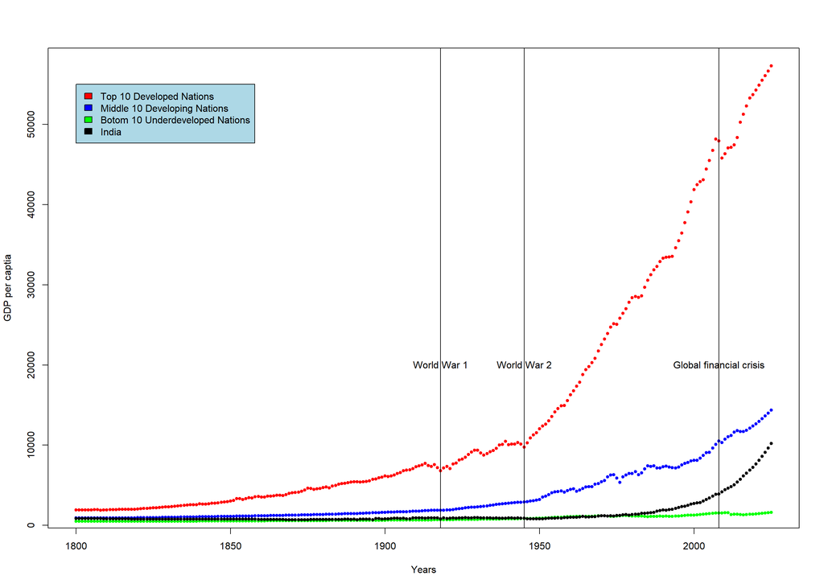

```r
plot(Years, topmeangdp, col = "red", pch = 20, ylab = "GDP per captia")
points(Years, middlemeangdp, col= " blue", pch = 20)
points(Years, bottommeangdp, col ="green", pch= 20)
points(Years, indiagdp, col = "black", pch = 20)
legend(1800, 55000, legend=c("Top 10 Developed Nations", "Middle 10 Developing Nations", "Botom 10 Underdeveloped Nations",  "India"), fill = c("red", "blue", "green", "black"), bg= "lightblue")
abline(v= 1918)
abline(v= 1945)
abline(v= 2008)
text(1918, 20075, "World War 1")
text(1945, 20075, "World War 2")
text(2008, 20075, "Global financial crisis")
```

## Observations

here we use abline to represent the important information retrive from plot

### World war 1 (~1918)

we can see dip in gdp during world war in developed counties more

### World war 2 (~1945)

we can see dip in gdp during world war in developed counties more

### Global financial crisis

india got very minimal impact , by comparison with other developed

## Testing Above observations

As India has shown a sharp change after independence it will be injustice to compare overall mean so we’ll also check before and after independence data too.

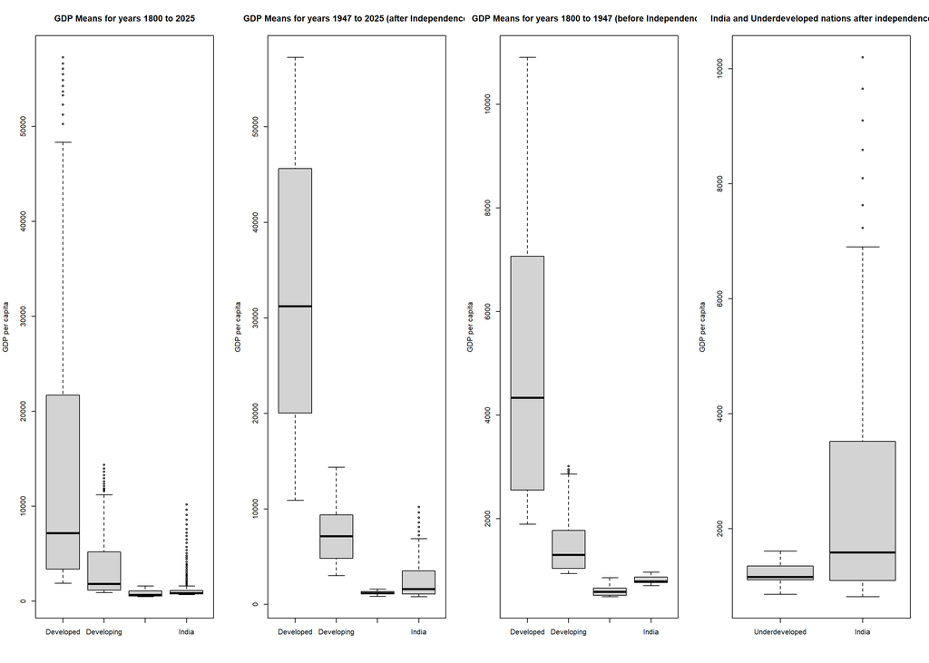

```r
par(mfrow=c(1,4))
boxplot(topmeangdp, middlemeangdp, bottommeangdp, indiagdp, names = c("Developed", "Developing", "Underdeveloped", "India"), ylab= "GDP per capita", main= "GDP Means for years 1800 to 2025")
boxplot(aitopmeangdp, aimiddlemeangdp, aibottommeangdp, aiindiagdp, names = c("Developed", "Developing", "Underdeveloped", "India"), ylab= "GDP per capita", main= "GDP Means for years 1947 to 2025 (after Independence)")
boxplot(bitopmeangdp, bimiddlemeangdp, bibottommeangdp, biindiagdp, names = c("Developed", "Developing", "Underdeveloped", "India"), ylab= "GDP per capita", main= "GDP Means for years 1800 to 1947 (before Independence)")
boxplot(aibottommeangdp, aiindiagdp, names = c("Underdeveloped", "India"), ylab= "GDP per capita", main= "India and Underdeveloped nations after independence")
```

By the above plots we can say India GDP has increased a lot after independence to check this hypothesis we will do some tests.

#### Saphiro test to check normality

**NULL Hypothesis**: The data is normal **Alternate Hypothesis**: The data is not normal

##### If P> 0.05 our NULL Hypothesis will be true

```r
shapiro.test(topmeangdp)
```

```
##
##  Shapiro-Wilk normality test
##
## data:  topmeangdp
## W = 0.76516, p-value < 2.2e-16
```

```r
shapiro.test(middlemeangdp)
```

```
##
##  Shapiro-Wilk normality test
##
## data:  middlemeangdp
## W = 0.76398, p-value < 2.2e-16
```

```r
shapiro.test(bottommeangdp)
```

```
##
##  Shapiro-Wilk normality test
##
## data:  bottommeangdp
## W = 0.85596, p-value = 1.003e-13
```

```r
shapiro.test(indiagdp)
```

```
##
##  Shapiro-Wilk normality test
##
## data:  indiagdp
## W = 0.48676, p-value < 2.2e-16
```

As the P values are less then 0.05 so our data is not normal

#### To further confirm we can do Q-Q plot

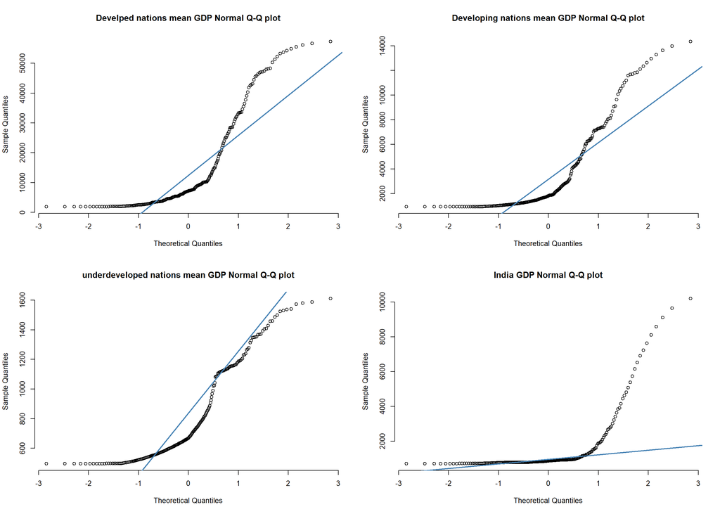

```r
par(mfrow=c(2,2) )
qqnorm(topmeangdp, pch = 1, frame = FALSE, main = "Develped nations mean GDP Normal Q-Q plot")
qqline(topmeangdp, col = "steelblue", lwd = 2)
qqnorm(middlemeangdp, pch = 1, frame = FALSE, main = "Developing nations mean GDP Normal Q-Q plot")
qqline(middlemeangdp, col = "steelblue", lwd = 2)
qqnorm(bottommeangdp, pch = 1, frame = FALSE, main = "underdeveloped nations mean GDP Normal Q-Q plot")
qqline(bottommeangdp, col = "steelblue", lwd = 2)
qqnorm(indiagdp, pch = 1, frame = FALSE, main = "India GDP Normal Q-Q plot")
qqline(indiagdp, col = "steelblue", lwd = 2)
```

From the above tests it is clear that the data sets are not normal so we can’t use parametric tests like **T test** or **ANOVA** to check weather means are same or not, so we will be using non parametric alternatives of those like **Wilcox** and **Kruskal** tests.

# Kruskal test

creating data frame

```r
gdpdataframe<- data.frame(values=c(topmeangdp, middlemeangdp, bottommeangdp, indiagdp), variable= c(rep("topmeangdp", length(topmeangdp)), rep("middlemeangdp", length(middlemeangdp)), rep("bottommeangdp", length(bottommeangdp)), rep("indiagdp", length(indiagdp))))
```

```r
kruskal.test(gdpdataframe$values~gdpdataframe$variable)
```

```
##
##  Kruskal-Wallis rank sum test
##
## data:  gdpdataframe$values by gdpdataframe$variable
## Kruskal-Wallis chi-squared = 573.59, df = 3, p-value < 2.2e-16
```

P values is significant so we can say the datas are differfent, so now we will do wilcoxon test for pairwise analysis

## Wilcoxon test

**NULL Hypotheis**: Mean of bottom ten countries is less than India before independence **Alternate Hypotheis**: Mean of bottom ten countries is greater than India before independence

```r
wilcox.test(bibottommeangdp, biindiagdp, paired = T, alternative = "greater")
```

```
##
##  Wilcoxon signed rank test with continuity correction
##
## data:  bibottommeangdp and biindiagdp
## V = 3, p-value = 1
## alternative hypothesis: true location shift is greater than 0
```

**NULL Hypotheis**: Mean of bottom ten countries is less than India after independence **Alternate Hypotheis**: Mean of bottom ten countries is greater than India after independence

```r
wilcox.test(aibottommeangdp, aiindiagdp, paired = T, alternative = "greater")
```

```
##
##  Wilcoxon signed rank test with continuity correction
##
## data:  aibottommeangdp and aiindiagdp
## V = 438, p-value = 1
## alternative hypothesis: true location shift is greater than 0
```

## How GDP per capita changed along with child per women

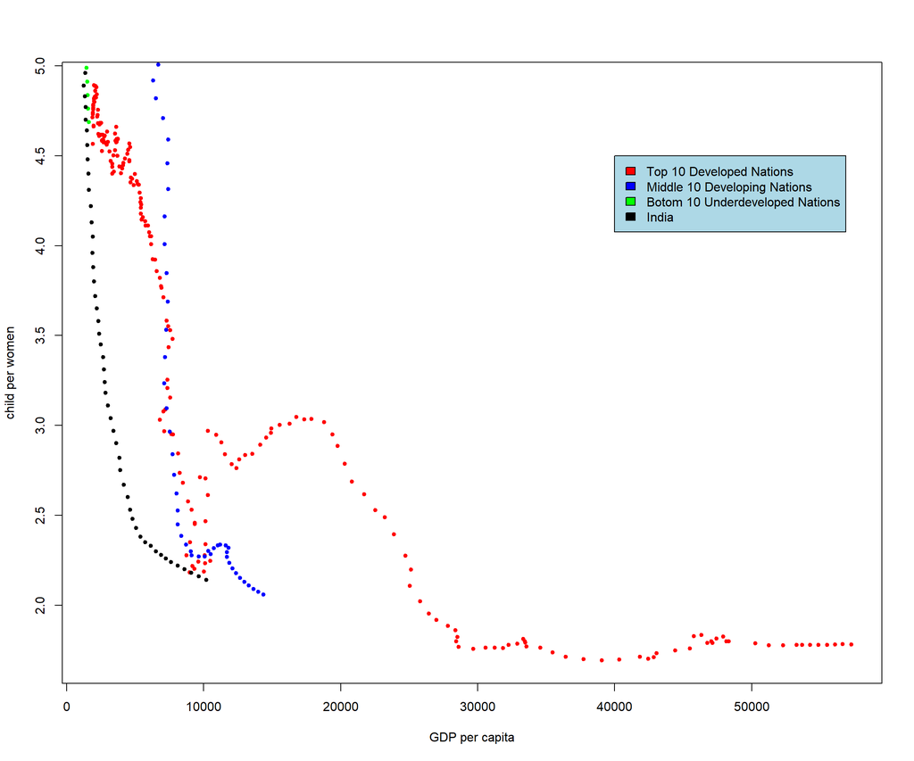

```r
plot(topmeangdp, topmeanchildrenperwomen, col = "red", pch = 20, xlab = "GDP per capita", ylab = "child per women")
points(middlemeangdp, middlemeanchildrenperwomen, col= " blue", pch = 20)
points(bottommeangdp, bottommeanchildrenperwomen, col ="green", pch= 20)
points(indiagdp, indiachildperwomen, col = "black", pch = 20)
legend(40000, 4.5, legend=c("Top 10 Developed Nations", "Middle 10 Developing Nations", "Botom 10 Underdeveloped Nations",  "India"), fill = c("red", "blue", "green", "black"), bg= "lightblue")
```

### Hypthesis With increase in GDP children per women decreases , to check this correlation we can do correlation tests.

#### Corelation test

```r
cor.test(topmeangdp, topmeanchildrenperwomen)
```

```
##
##  Pearson's product-moment correlation
##
## data:  topmeangdp and topmeanchildrenperwomen
## t = -23.085, df = 224, p-value < 2.2e-16
## alternative hypothesis: true correlation is not equal to 0
## 95 percent confidence interval:
##  -0.8738958 -0.7957202
## sample estimates:
##        cor
## -0.8390882
```

As the cor value is in negative it means with increase of GDP children per women decreases

## How population changed with gdp per capita

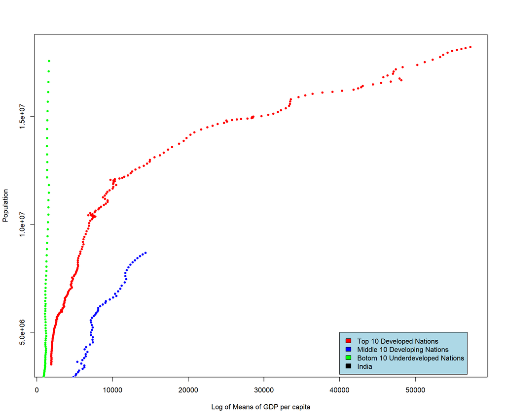

```r
plot(topmeangdp, topmeanpopulation, col = "red", pch = 20, xlab = "Log of Means of GDP per capita", ylab = "Population")
points(middlemeangdp, middlemeanpopulation, col= " blue", pch = 20)
points(bottommeangdp, bottommeanpopulation, col ="green", pch= 20)
points(indiagdp, indiapopulation, col = "black", pch = 20)
legend(40000, 5000000, legend=c("Top 10 Developed Nations", "Middle 10 Developing Nations", "Botom 10 Underdeveloped Nations",  "India"), fill = c("red", "blue", "green", "black"), bg= "lightblue")
```

### Hypthesis

With increase in GDP population als increasing, to check this correlation we can do correlation tests.

#### Corelation test

```r
cor.test(topmeangdp, topmeanpopulation)
```

```
##
##  Pearson's product-moment correlation
##
## data:  topmeangdp and topmeanpopulation
## t = 30.203, df = 224, p-value < 2.2e-16
## alternative hypothesis: true correlation is not equal to 0
## 95 percent confidence interval:
##  0.8668906 0.9190577
## sample estimates:
##       cor
## 0.8960241
```

As the cor value is in postive it means with increase of GDP population increase